# Chapter 5

Tuomas Mäkelä

30 11 2019

# Week 5 is for fun!

## Data, right?

### No. The *correct* way to address a senior officer is “Lieutnant Data”.

This week we will look into the human dataset from the UN report of 2015. The data looks following:

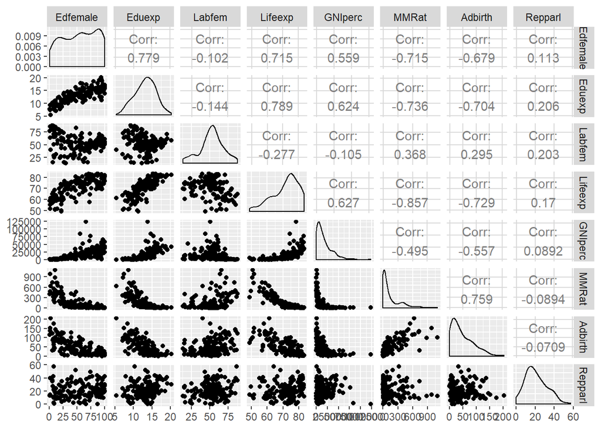

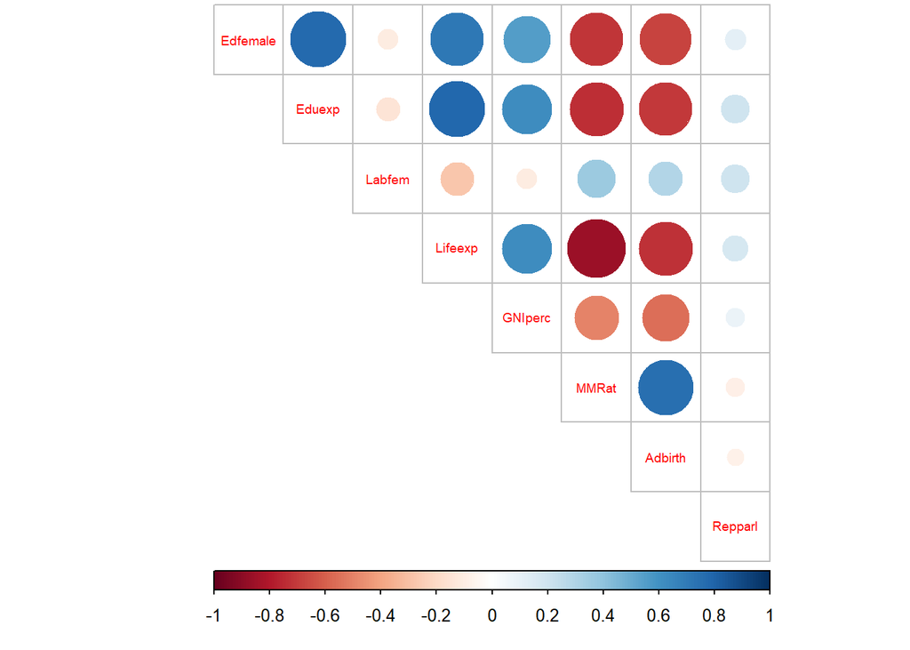

```
##     Edfemale          Eduexp          Labfem         Lifeexp
##  Min.   :  0.90   Min.   : 5.40   Min.   :13.50   Min.   :49.00
##  1st Qu.: 27.15   1st Qu.:11.25   1st Qu.:44.45   1st Qu.:66.30
##  Median : 56.60   Median :13.50   Median :53.50   Median :74.20
##  Mean   : 55.37   Mean   :13.18   Mean   :52.52   Mean   :71.65
##  3rd Qu.: 85.15   3rd Qu.:15.20   3rd Qu.:61.90   3rd Qu.:77.25
##  Max.   :100.00   Max.   :20.20   Max.   :88.10   Max.   :83.50
##     GNIperc           MMRat           Adbirth          Repparl
##  Min.   :   581   Min.   :   1.0   Min.   :  0.60   Min.   : 0.00
##  1st Qu.:  4198   1st Qu.:  11.5   1st Qu.: 12.65   1st Qu.:12.40
##  Median : 12040   Median :  49.0   Median : 33.60   Median :19.30
##  Mean   : 17628   Mean   : 149.1   Mean   : 47.16   Mean   :20.91
##  3rd Qu.: 24512   3rd Qu.: 190.0   3rd Qu.: 71.95   3rd Qu.:27.95
##  Max.   :123124   Max.   :1100.0   Max.   :204.80   Max.   :57.50
```

It seems that the variables are numeric, with some represented as percentages. The ratio of women in the labour force seems not to correllate with the rest of the bunch, while others have high correlations. Specifically, the education of women, education expectancy and life expectancy correlate highly with adolescent birth rate, maternal mortality and GNI per capita. This is to be expected since the more women educate themselves, the later they generally have children and high education rates lead to low mortalities. Life expectancy obviously correllates with maternal mortality and eduexp with edufem, but these seem to be quite obvious correllations to the educated reader.

The other two variables seem to have much lower correllations with the rest of the stuff, but seem quite similar to each other in that respect. Both represent somehow the working status of women.

## 2. PCA or finding the true variables

PCA is used to find the relevant variable combinations in the dataset. Since many of the variables correlate, this seems a prudent approach to reducing the dimensionality of the data.

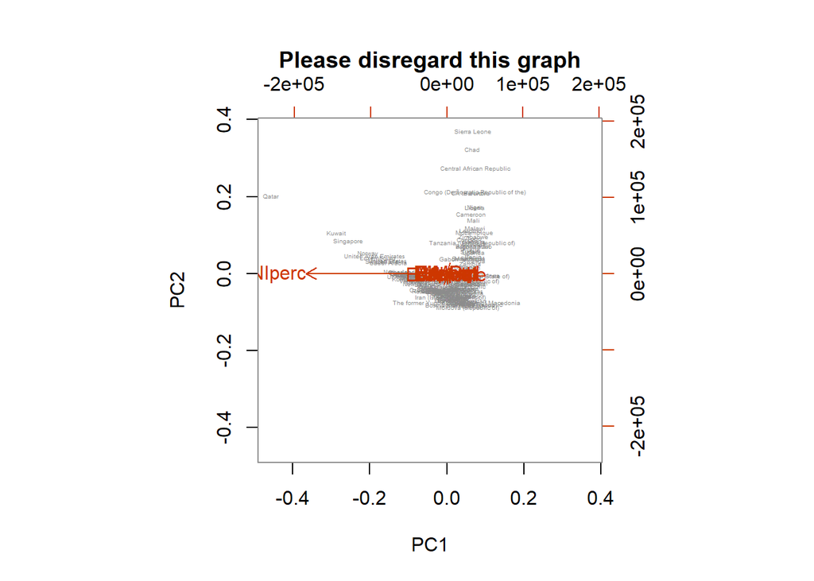

as that’s just horrible. PCA doesn’t seem to like the distribution of some of the variables. This seems reasonable, since GNIperc and others have distributions that are far different from the rest of the crew.

The only principal component the analysis detects is GNI. This seems prudent, since the values of that variable are by FAR greater than most of the other ones. This leads to the analysis running to almost zero components for the rest of the stuff, so let’s just not look at that ever again.

Now we will standardize the data and try it again.

```r
human_std<-scale(Human)
summary(human_std)
```

```
##     Edfemale            Eduexp            Labfem            Lifeexp
##  Min.   :-1.76122   Min.   :-2.7378   Min.   :-2.43186   Min.   :-2.7188
##  1st Qu.:-0.91250   1st Qu.:-0.6782   1st Qu.:-0.50289   1st Qu.:-0.6425
##  Median : 0.03967   Median : 0.1140   Median : 0.06116   Median : 0.3056
##  Mean   : 0.00000   Mean   : 0.0000   Mean   : 0.00000   Mean   : 0.0000
##  3rd Qu.: 0.96275   3rd Qu.: 0.7126   3rd Qu.: 0.58469   3rd Qu.: 0.6717
##  Max.   : 1.44288   Max.   : 2.4730   Max.   : 2.21762   Max.   : 1.4218
##     GNIperc            MMRat            Adbirth           Repparl
##  Min.   :-0.9193   Min.   :-0.6992   Min.   :-1.1325   Min.   :-1.8203
##  1st Qu.:-0.7243   1st Qu.:-0.6496   1st Qu.:-0.8394   1st Qu.:-0.7409
##  Median :-0.3013   Median :-0.4726   Median :-0.3298   Median :-0.1403
##  Mean   : 0.0000   Mean   : 0.0000   Mean   : 0.0000   Mean   : 0.0000
##  3rd Qu.: 0.3712   3rd Qu.: 0.1932   3rd Qu.: 0.6030   3rd Qu.: 0.6127
##  Max.   : 5.6890   Max.   : 4.4899   Max.   : 3.8344   Max.   : 3.1850
```

We see that now the variables are centered with std = 1. Now for some PCA!

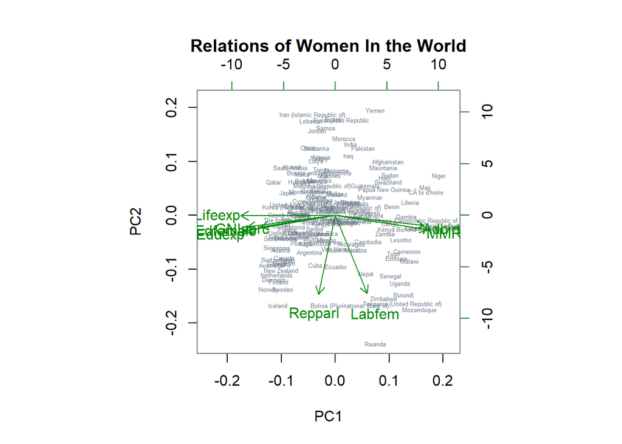

That looks immensely better. The PC1 component seems to correspond to Education rate of women and the GNI of the country. These are highly correllated as we saw in the first plot and it seems prudent that joint component representing all these variables be created. The second component contains the variables for female labour and the ratio of women in parliament. This seems to indicate that both the variables are measuring similar things. One would be tempted to say that the respect for women is among them, but we will refrain from making such quick inferences based on only one analysis.

Looking again at the correlation plot done on the data matrix first, we see that the PCA detects sets of variables related to one another.